# Fitting meta-analysis with the `glmmTMB` R package

- Show All Code
- Hide All Code
- View Source

Author

Coralie Williams

Published

September 26, 2026

Below, we show how to fit a meta-analysis using the `equalto` covariance structure in `glmmTMB` R package (Brooks et al. 2017), which allows users to specify the known sampling error variance-covariance (VCV) matrix.

### Contact

For any questions or to raise an error, please contact: Coralie Williams

Last updated: 26 September 2026

# 1 Introduction

To demonstrate how to fit a meta-analysis using the `glmmTMB` R package (Brooks et al. 2017), we will fit a multilevel meta-analytic model assuming multiple effect sizes per study. This model synthesises effect sizes across studies by accounting for variation at both the study and observation (effect size) levels, while also modelling correlated sampling errors within studies.

Given $j$ effect sizes within $i$ studies, we specify the model as:

$$y_{ij} = b_0 + u_i + m_{ij} + e_{ij},$$

where $b_0$ is the overall mean effect, $u_i \sim N(0, \sigma^2_{u}I)$ represents the among-study random effect, $m_{ij} \sim N(0, \sigma^2_{m}I)$ captures the within-study random effect (at the observation-level), and $e_{ij} \sim N(0, \text{VCV})$ are the sampling errors at the observation-level.

$\text{VCV}$ represents a block-diagonal variance-covariance matrix including known (or calculated) sampling variances $\sigma^2_{e}=v_i$ on the diagonal and accounts for correlations among sampling errors from the same study.

### Load libraries

```r
# load libraries
  library(MASS)
  library(kableExtra)
  library(metafor)
  library(glmmTMB)
  library(tidyverse)
```

Check if the `equalto` covariance structure is available (it should be in position 15 of this output):

```r
glmmTMB:::.valid_covstruct
```

```
   diag      us      cs     ar1      ou     exp     gau     mat    toep      rr
      0       1       2       3       4       5       6       7       8       9
homdiag  propto  hetar1   homcs homtoep equalto
     10      11      12      13      14      15
```

### Simulate some data

Now, let’s simulate some data following the structure of the above multilevel meta-analysis.

```r
# set up indices
k.studies <- 10 # number of studies
k.per.study <- 3 # number of effect sizes per study
study <- rep(seq_len(k.studies), times=k.per.study) # study id
k <- length(study) # total number of effect sizes
id <- seq_len(k) # id of between study effect sizes
es.id <- unlist(lapply(k.per.study, seq_len)) # id of within study effect sizes


# fixed effect coeff true value (i.e. the overall mean)
b0 <- 0

# simulate sampling errors variances
set.seed(123)
vi <- rbeta(k, 2, 20)

# get VCV matrix assuming within-study correlation of rho=0.5
V <- matrix(0, nrow = k, ncol = k)
for (i in 2:k) {
  for (j in 1:i) {
    if (study[i] == study[j]) {
      V[i,j] <- 0.5 * sqrt(vi[i] * vi[j])
    }
  }
}
V[upper.tri(V)] <- t(V)[upper.tri(V)] # fill in upper diagonal
diag(V) <- vi # fill in diagonal


# random effects
sigma2.u <- 0.2
sigma2.m <- 0.3
u <- rnorm(k.studies, 0, sqrt(sigma2.u))[study]
m <- rnorm(k, 0, sqrt(sigma2.m))

# simulate multivariate normal sampling errors with specific VCV
# (re-seeded so this draw doesn't depend on the number of random draws above)
set.seed(123)
e <- mvrnorm(n = 1, mu = rep(0, length(vi)), Sigma = V)
#e <- rnorm(k, 0, sqrt(vi))[study] #without within-study correlation (diag VCV)

# compute y
y <- b0 + u + m + e


# combine into dataframe
dat <- data.frame(y = y,
                  vi = vi,
                  study = study,
                  id = id,
                  es.id = es.id,
                  obs = as.factor(id), #unique ID for propto and equalto (really important it is a factor variable)
                  g = 1 #group ID for propto and equalto (a constant here)
)
```

### Fit `glmmTMB` model

Before we fit the model we need to obtain the within-study error variance-covariance matrix (which accounts for within-study correlation) assuming a constant correlation of $\rho=0.5$. The correlation between effect sizes from different studies is assumed to be zero.

We use the metafor `vcalc` function to obtain a block diagonal VCV matrix for the sampling errors:

```r
VCV <- metafor::vcalc(vi, cluster=study, obs=obs, data=dat, rho=0.5)

# make sure the VCV row/column names match the levels (and order) of the
# `obs` random effect variable used in the equalto() term below
dimnames(VCV) <- list(levels(dat$obs), levels(dat$obs))
```

**Important**

**Row and column names of the VCV matrix must match the levels of the `equalto` random effect variable, and be in the same order.** `glmmTMB` matches rows/columns of the VCV matrix to random effect levels. Always set `dimnames(VCV) <- list(levels(your_factor), levels(your_factor))` (or `rownames()`/`colnames()`) right after constructing the matrix, as shown above.

Now we fit the `glmmTMB` model with `equalto` covariance structure.

We specify:

- the study-level random effect $u_i$ as `(1|study)`.
- the sampling errors $e_{ij}$ are specified using the covariance structure `equalto(0 + obs|g,VCV)` allowing to specify the VCV matrix of the sampling errors.
- the within-study random effect $m_{ij}$ that captures the variability at the observation level is modelled as the *residual error* in this model.

**Note**

The `equalto` multivariate random effect variable (here it is called `obs`) must be a factor.

```r
# Fit glmmTMB model with equalto ----------------------------------
fit.equalto <- glmmTMB(y ~ 1 + (1|study) + equalto(0 + obs|g,VCV),
                       data=dat,
                       REML=T)

# > summary(fit.equalto)
#
#  Family: gaussian  ( identity )
# Formula:          y ~ 1 + (1 | study) + equalto(0 + obs | g, VCV)
# Data: dat
#
#       AIC       BIC    logLik -2*log(L)  df.resid
#      61.3      65.5     -27.6      55.3        27
#
# Random effects:
#
# Conditional model:
#  Groups   Name        Variance Std.Dev. Corr
#  study    (Intercept) 0.03440  0.1855
#  g        obs1        0.05545  0.2355
#           obs2        0.07455  0.2730   0.00
#           obs3        0.33583  0.5795   0.00 0.00
#           obs4        0.09652  0.3107   0.00 0.00 0.00
#           obs5        0.10144  0.3185   0.00 0.00 0.00 0.00
#           obs6        0.13395  0.3660   0.00 0.00 0.00 0.00 0.00
#           obs7        0.02728  0.1652   0.00 0.00 0.00 0.00 0.00 0.00
#           obs8        0.04926  0.2220   0.00 0.00 0.00 0.00 0.00 0.00 0.00
#           obs9        0.06157  0.2481   0.00 0.00 0.00 0.00 0.00 0.00 0.00 0.00
#           obs10       0.12738  0.3569   0.00 0.00 0.00 0.00 0.00 0.00 0.00 0.00 0.00
#           ...         ...      ...      ...  ...  ...  ...  ...  ...  ...  ...  ...  ...
#  Residual             0.25008  0.5001
# Number of obs: 30, groups:  study, 10; g, 1
#
# Dispersion estimate for gaussian family (sigma^2): 0.25
#
# Conditional model:
#             Estimate Std. Error z value Pr(>|z|)
# (Intercept) 0.005619   0.131220   0.043    0.966
```

### Fit `metafor` model

Let’s compare with the `metafor` package `rma.mv` function that fits a multilevel model with random effects. Here the model is specified with two random effects: `(1|study)` corresponding to the among-study ($u_i$) and `(1|id)` corresponding to the within-study ($m_{ij}$) random effects. The sampling errors $e_{ij}$ VCV matrix is specified using the `V` argument.

```r
# Fit metafor model --------------------------------------------
fit.metafor <- rma.mv(yi = y,
                      V = VCV,
                      random = list(~1 | study, ~1 | id),
                      control=list(REMLf=FALSE),
                      data = dat) #uses REML by default

# > summary(fit.metafor)
#
# Multivariate Meta-Analysis Model (k = 30; method: REML)
#
#   logLik  Deviance       AIC       BIC      AICc
# -27.6455   55.2911   61.2911   65.3930   62.2511
#
# Variance Components:
#
#             estim    sqrt  nlvls  fixed  factor
# sigma^2.1  0.0344  0.1855     10     no   study
# sigma^2.2  0.2501  0.5001     30     no      id
#
# Test for Heterogeneity:
# Q(df = 29) = 207.0443, p-val < .0001
#
# Model Results:
#
# estimate      se    zval    pval    ci.lb   ci.ub
#   0.0056  0.1310  0.0429  0.9658  -0.2511  0.2624
#
# ---
# Signif. codes:  0 ‘***’ 0.001 ‘**’ 0.01 ‘*’ 0.05 ‘.’ 0.1 ‘ ’ 1
```

**Tip**

`control=list(REMLf=FALSE)` is needed to obtain the exact same REML likelihood value from `rma.mv()` as `glmmTMB()` reports; the two packages otherwise use slightly different REML likelihood calculations.

Then, we extract the model results for each model and compare outputs:

```r
### Compare output
equalto <- data.frame(model = "glmmTMB",
                      est = coef(summary(fit.equalto))$cond[,"Estimate"],
                      se = coef(summary(fit.equalto))$cond[,"Std. Error"],
                      zval = coef(summary(fit.equalto))$cond[,"z value"],
                      pval = coef(summary(fit.equalto))$cond[,"Pr(>|z|)"],
                      sigma.u = VarCorr(fit.equalto)$cond$study[,"(Intercept)"], ##among study variance estimate
                      sigma.m = sigma(fit.equalto)^2) ##within study variance estimate


metafor <- data.frame(model = "metafor",
                      est = coef(fit.metafor)[1],
                      se = se(fit.metafor)[1],
                      zval = fit.metafor$zval,
                      pval = fit.metafor$pval,
                      sigma.u = fit.metafor$sigma2[1], ## among study variance
                      sigma.m = fit.metafor$sigma2[2]) ## within study variance


output <- rbind(equalto, metafor)
kable(output)
```

|  | model | est | se | zval | pval | sigma.u | sigma.m |
| --- | --- | --- | --- | --- | --- | --- | --- |
| 1 | glmmTMB | 0.0056193 | 0.1312196 | 0.0428234 | 0.9658423 | 0.0344011 | 0.2500832 |
| intrcpt | metafor | 0.0056193 | 0.1310007 | 0.0428949 | 0.9657853 | 0.0344011 | 0.2500831 |

The overall mean estimate and random effect variance estimates are identical across the two packages.

### Derive adjusted $t$-distribution p-values

When the number of studies is small (<10) it is preferable to use the $t$-distribution and adjusted degrees of freedom to avoid Type I error rate of coefficient tests and low coverage rates of coefficient confidence intervals ([read more about the recommendations here](https://wviechtb.github.io/metafor/reference/misc-recs.html)).

In `metafor` you can do this directly in the `rma.mv` function when fitting a multilevel/multivariate model with the arguments `test="t"` and `dfs="contain"` (actually if `dfs="contain"` is set this automatically sets `test="t"`).

```r
# Fit metafor model --------------------------------------------
fit.metafor.t <- rma.mv(yi = y,
                      V = VCV,
                      random = list(~1 | study, ~1 | id),
                      test = "t",
                      dfs = "contain",
                      data = dat)

summary(fit.metafor.t)
```

```
Multivariate Meta-Analysis Model (k = 30; method: REML)

  logLik  Deviance       AIC       BIC      AICc
-25.9449   51.8899   57.8899   61.9918   58.8499

Variance Components:

            estim    sqrt  nlvls  fixed  factor
sigma^2.1  0.0344  0.1855     10     no   study
sigma^2.2  0.2501  0.5001     30     no      id

Test for Heterogeneity:
Q(df = 29) = 207.0443, p-val < .0001

Model Results:

estimate      se    tval  df    pval    ci.lb   ci.ub
  0.0056  0.1310  0.0429   9  0.9667  -0.2907  0.3020

---
Signif. codes:  0 '***' 0.001 '**' 0.01 '*' 0.05 '.' 0.1 ' ' 1
```

With `glmmTMB` you can derive the $t$-test statistic, adjusted degrees of freedom and corresponding P value the following way:

```r
# summary stats of fixed effects
fef <- as.data.frame(summary(fit.equalto)$coefficients$cond)
b0.est <- fef$Estimate
b0.se <- fef$`Std. Error`

# if the coefficient of interest varies at the level corresponding to a random effect (i.e. here it is `study`) then the degrees of freedom are the number of unique levels minus the number of estimated coefficients in the model
df.contain <- length(unique(dat$study)) - nrow(fef)
# otherwise it is the total number of estimates in the analysis minus the total number of model coefficients
#df.adj <- nrow(dat) - nrow(fef)

# get t-test statistic and p-value
t <- b0.est / b0.se
p <- 2 * pt(abs(t), df = df.contain, lower.tail = FALSE) # two-sided p value
# 95% CI
crit <- qt(0.975, df = df.contain)
ci   <- c(b0.est - crit * b0.se, b0.est + crit * b0.se)

# glmmTMB t-test output
fef.t <- data.frame(Estimate = b0.est,
                    SE = b0.se,
                    tval = t,
                    df = df.contain,
                    pval = p,
                    ci.lb = ci[1],
                    ci.ub = ci[2])
fef.t
```

| Estimate | SE | tval | df | pval | ci.lb | ci.ub |
| --- | --- | --- | --- | --- | --- | --- |
| 0.0056193 | 0.1312196 | 0.0428234 | 9 | 0.9667773 | -0.29122 | 0.3024585 |

# 2 Illustrative examples

To illustrate the range of meta-analytic models that can be fitted with `glmmTMB`, we re-analyse four published datasets from different research domains:

- **Bivariate meta-analysis** — applied to a medical dataset on vaccine effectiveness.
- **Network meta-analysis** — applied to a psychology dataset comparing multiple interventions.
- **Phylogenetic meta-analysis** — applied to an ecology and evolution dataset on the effects of plant diversity.
- **Location–scale meta-analysis** — applied to a social science dataset evaluating school-based learning programs.

For each case study, we demonstrate model specification, output, and interpretation using `glmmTMB`. We also fit equivalent models using the `metafor` package (when possible) and compare the resulting estimates across packages.

## 2.1 Bivariate meta-analysis

Meta-analysis is widely used in medicine to combine evidence across clinical trials and observational studies. As many outcomes in medicine are events, common effect size measures are odds ratios, risk ratios, risk differences, and their log transforms.

We will use the Colditz et al. (1994) dataset that is directly avaiable in `metafor` via the `metadat` R package (T. White et al. 2022). This published meta-analysis assessed the effectiveness of the Bacillus Calmette-Guerin (BCG) vaccine against tuberculosis across 13 studies. We will fit a bivariate meta-analysis that treats the two vaccination groups as separate outcomes, and estimates, for each group, the overall mean effect and among-study variance, as well as the correlation of study-level effects between groups (i.e., how strongly they co-vary).

```r
dat <- dat.colditz1994
```

Reshape to long format so that each arm has its own row (“v” = vaccinated, “c” = unvaccinated/control), and set control as the reference group.

```r
dat_long <- to.long(measure="OR", ai=tpos, bi=tneg, ci=cpos, di=cneg, data=dat)
levels(dat_long$group) <- c("c", "v")
dat_long$group <- relevel(dat_long$group, ref="c")
```

We compute the logit-transformed event proportion (`PLO`) as the effect-size measure. And we also need to create a constant grouping dummy variable `g` for `glmmTMB` model specification (this needs to be a constant value for all rows).

```r
dat_long <- escalc(measure="PLO", xi=out1, mi=out2, data=dat_long)
dat_long$obs <- as.factor(1:nrow(dat_long))
dat_long$g <- 1 #dummy variable
head(dat_long)
```

| trial | author | year | tpos | tneg | cpos | cneg | ablat | alloc | study | group | out1 | out2 | yi | vi | obs | g |
| --- | --- | --- | --- | --- | --- | --- | --- | --- | --- | --- | --- | --- | --- | --- | --- | --- |
| 1 | Aronson | 1948 | 4 | 119 | 11 | 128 | 44 | random | 1 | v | 4 | 119 | -3.392829 | 0.2584034 | 1 | 1 |
| 1 | Aronson | 1948 | 4 | 119 | 11 | 128 | 44 | random | 1 | c | 11 | 128 | -2.454135 | 0.0987216 | 2 | 1 |
| 2 | Ferguson & Simes | 1949 | 6 | 300 | 29 | 274 | 55 | random | 2 | v | 6 | 300 | -3.912023 | 0.1700000 | 3 | 1 |
| 2 | Ferguson & Simes | 1949 | 6 | 300 | 29 | 274 | 55 | random | 2 | c | 29 | 274 | -2.245832 | 0.0381324 | 4 | 1 |
| 3 | Rosenthal et al | 1960 | 3 | 228 | 11 | 209 | 42 | random | 3 | v | 3 | 228 | -4.330733 | 0.3377193 | 5 | 1 |
| 3 | Rosenthal et al | 1960 | 3 | 228 | 11 | 209 | 42 | random | 3 | c | 11 | 209 | -2.944439 | 0.0956938 | 6 | 1 |

Derive the variance-covariance matrix (VCV), with the sampling error variances on the diagonal and zero on the off-diagonals (assume studies are independent):

```r
VCV <- diag(dat_long$vi)

# make sure the VCV row/column names match the levels of the `obs` random
# effect variable used in the equalto() term below
dimnames(VCV) <- list(levels(dat_long$obs), levels(dat_long$obs))
VCV[1:5,1:5] #show first five measures of VCV matrix
```

```
          1          2    3          4         5
1 0.2584034 0.00000000 0.00 0.00000000 0.0000000
2 0.0000000 0.09872159 0.00 0.00000000 0.0000000
3 0.0000000 0.00000000 0.17 0.00000000 0.0000000
4 0.0000000 0.00000000 0.00 0.03813239 0.0000000
5 0.0000000 0.00000000 0.00 0.00000000 0.3377193
```

**Important**

As before, the row and column names of `VCV` must match the levels of the `obs` random effect variable, and be in the same order.

To fit a bivariate meta-analysis with `glmmTMB` using `equalto` supply the sampling-error variance–covariance matrix (here it is called `VCV`).

```r
bv_fit <- glmmTMB(yi ~ group + (0 + group|study) + equalto(0 + obs|g,VCV),
                       dispformula = ~ 0,
                       REML = TRUE,
                       data=dat_long)
```

**Tip**

`dispformula = ~ 0` fixes the residual (dispersion) variance at zero, since here the only within-study variability we want to model comes from the `equalto()` sampling-error VCV, not from an additional residual term.

```r
# > summary(bv_fit)
#  Family: gaussian  ( identity )
# Formula:          yi ~ group + (0 + group | study) + equalto(0 + obs | g, VCV)
# Dispersion:          ~0
# Data: dat_long
#
#       AIC       BIC    logLik -2*log(L)  df.resid
#      78.1      84.4     -34.1      68.1        21
#
# Random effects:
#
# Conditional model:
#  Groups Name   Variance Std.Dev. Corr
#  study  groupc 2.617300 1.61781
#         groupv 1.548603 1.24443  0.95
#  g      obs1   0.258403 0.50833
#         obs2   0.098722 0.31420  0.00
#         obs3   0.170000 0.41231  0.00 0.00
#         obs4   0.038132 0.19528  0.00 0.00 0.00
#         obs5   0.337719 0.58114  0.00 0.00 0.00 0.00
#         obs6   0.095694 0.30934  0.00 0.00 0.00 0.00 0.00
#         obs7   0.016203 0.12729  0.00 0.00 0.00 0.00 0.00 0.00
#         obs8   0.004112 0.06412  0.00 0.00 0.00 0.00 0.00 0.00 0.00
#         obs9   0.030502 0.17465  0.00 0.00 0.00 0.00 0.00 0.00 0.00 0.00
#         obs10  0.021450 0.14646  0.00 0.00 0.00 0.00 0.00 0.00 0.00 0.00 0.00
#         ...    ...      ...      ...  ...  ...  ...  ...  ...  ...  ...  ...  ...
# Number of obs: 26, groups:  study, 13; g, 1
#
# Conditional model:
#             Estimate Std. Error z value Pr(>|z|)
# (Intercept)  -4.0960     0.4530  -9.042  < 2e-16 ***
# groupv       -0.7414     0.1892  -3.918 8.94e-05 ***
# ---
# Signif. codes:  0 ‘***’ 0.001 ‘**’ 0.01 ‘*’ 0.05 ‘.’ 0.1 ‘ ’ 1
#



# # We can also get the  estimated marginal means
# emmeans::emmeans(bv_fit, ~ group) |>
#   summary(infer=TRUE, type="response")
```

To obtain the variance component estimates and corresponding correlation $\rho$ (i.e. `rho`) for each group we use the `VarCorr` function:

```r
vc <- VarCorr(bv_fit)
var_con <- vc$cond$study["groupc", "groupc"]
var_exp <- vc$cond$study["groupv", "groupv"]
rho.tmb <- vc$cond$study["groupc", "groupv"] / sqrt(var_con * var_exp)
```

Then we can extract the model results as follows:

```r
bv_out <- data.frame(est.b0 = as.numeric(coef(summary(bv_fit))$cond[,"Estimate"][1]),
                     se.b0 = as.numeric(coef(summary(bv_fit))$cond[,"Std. Error"][1]),
                     est.b1 = as.numeric(coef(summary(bv_fit))$cond[,"Estimate"][2]),
                     se.b1 = as.numeric(coef(summary(bv_fit))$cond[,"Std. Error"][2]),
                     tau2_1 = var_con, #study-level heterogeneity for group=control
                     tau2_2 = var_exp, #study-level heterogeneity for group=exp
                     rho = rho.tmb)

bv_out
```

| est.b0 | se.b0 | est.b1 | se.b1 | tau2_1 | tau2_2 | rho |
| --- | --- | --- | --- | --- | --- | --- |
| -4.095985 | 0.4529815 | -0.7413877 | 0.1892434 | 2.6173 | 1.548603 | 0.9450462 |

This is equivalent to the following model in `metafor`:

```r
bv_fit_rma <- rma.mv(yi, vi, mods = ~ group,
                     random = ~ group | study,
                     struct = "UN",
                     data=dat_long)

# summary(bv_fit_rma)
#
# Multivariate Meta-Analysis Model (k = 26; method: REML)
#
#   logLik  Deviance       AIC       BIC      AICc
# -31.5017   63.0033   73.0033   78.8936   76.3367
#
# Variance Components:
#
# outer factor: study (nlvls = 13)
# inner factor: group (nlvls = 2)
#
#             estim    sqrt  k.lvl  fixed  level
# tau^2.1    2.6173  1.6178     13     no      c
# tau^2.2    1.5486  1.2444     13     no      v
#
#     rho.c  rho.v     c   v
# c       1            -  13
# v  0.9450      1    no   -
#
# Test for Residual Heterogeneity:
# QE(df = 24) = 5270.3863, p-val < .0001
#
# Test of Moderators (coefficient 2):
# QM(df = 1) = 15.5470, p-val < .0001
#
# Model Results:
#
#          estimate      se     zval    pval    ci.lb    ci.ub
# intrcpt   -4.0960  0.4529  -9.0432  <.0001  -4.9837  -3.2082  ***
# groupv    -0.7414  0.1880  -3.9430  <.0001  -1.1099  -0.3729  ***
#
# ---
# Signif. codes:  0 ‘***’ 0.001 ‘**’ 0.01 ‘*’ 0.05 ‘.’ 0.1 ‘ ’ 1
```

We can extract the model results as follows:

```r
bv_out_rma <- with(bv_fit_rma, data.frame(est.b0 = as.numeric(b[1]),
                                      se.b0 = se[1],
                                      est.b1 = as.numeric(b[2]),
                                      se.b1 = se[2],
                                      tau2_1 = tau2[1],
                                      tau2_2 = tau2[2],
                                      rho = rho))
bv_out_rma
```

| est.b0 | se.b0 | est.b1 | se.b1 | tau2_1 | tau2_2 | rho |
| --- | --- | --- | --- | --- | --- | --- |
| -4.095985 | 0.452937 | -0.7413877 | 0.1880277 | 2.6173 | 1.548603 | 0.9450462 |

We can also fit the GLMM specification of the same bivariate model by taking the joint distribution of the probability of an event in the treatment and control groups of each study. This model is sometimes called the “Van Houwelingen bivariate” model.

```r
dat_long <- dat_long |>
  mutate(vacc = as.integer(group == "v"),
    cont = as.integer(group == "c"))
```

Now fit the model with glmmTMB function:

```r
bv_joint_fit <- glmmTMB(cbind(out1,out2) ~ factor(vacc) + (cont+vacc-1|study),
                        family = binomial(link = "logit"),
                        data=dat_long)


# > summary(bv_joint_fit)
#
#  Family: binomial  ( logit )
# Formula:          cbind(out1, out2) ~ factor(vacc) + (cont + vacc - 1 | study)
# Data: dat_long
#
#       AIC       BIC    logLik -2*log(L)  df.resid
#     257.4     263.7    -123.7     247.4        21
#
# Random effects:
#
# Conditional model:
#  Groups Name Variance Std.Dev. Corr
#  study  cont 2.438    1.561
#         vacc 1.436    1.198    0.95
# Number of obs: 26, groups:  study, 13
#
# Conditional model:
#               Estimate Std. Error z value Pr(>|z|)
# (Intercept)    -4.1234     0.4374  -9.427  < 2e-16 ***
# factor(vacc)1  -0.7417     0.1834  -4.043 5.27e-05 ***
# ---
# Signif. codes:  0 ‘***’ 0.001 ‘**’ 0.01 ‘*’ 0.05 ‘.’ 0.1 ‘ ’ 1
```

```r
vc <- VarCorr(bv_joint_fit)
var_cont <- vc$cond$study["cont", "vacc"]
var_vacc <- vc$cond$study["vacc", "vacc"]
rho.tmb <- vc$cond$study["cont", "vacc"] / sqrt(var_cont * var_vacc)


bv_joint_out <- data.frame(est.b0 = as.numeric(coef(summary(bv_joint_fit))$cond[,"Estimate"][1]),
                     se.b0 = as.numeric(coef(summary(bv_joint_fit))$cond[,"Std. Error"][1]),
                     est.b1 = as.numeric(coef(summary(bv_joint_fit))$cond[,"Estimate"][2]),
                     se.b1 = as.numeric(coef(summary(bv_joint_fit))$cond[,"Std. Error"][2]),
                     tau2_1 = var_cont, #study-level heterogeneity for group=control
                     tau2_2 = var_vacc, #study-level heterogeneity for group=vaccine
                     rho = rho.tmb)

bv_joint_out
```

[output not shown]

## 2.2 Network meta-analysis

When several treatments are compared across a set of studies, a network meta-analysis can be used. It allows treatments to be compared even when they were not directly compared in the same study, provided they are connected through other treatment comparisons. This allows all treatments in the network to be compared within one model.

We use the Hasselblad (1998) dataset from the `metadat` R package (T. White et al. 2022). It contains 24 studies comparing four smoking-cessation conditions: no contact, self-help, individual counselling and group counselling. For each study arm, the dataset records the number of individuals who remained abstinent for 6 to 12 months and the total number of individuals. Most studies compared two conditions, while two studies compared three.

```r
dat <- metadat::dat.hasselblad1998
head(dat)
```

| id | study | authors | year | trt | xi | ni |
| --- | --- | --- | --- | --- | --- | --- |
| 1 | 1 | Reid et al. | 1974 | no_contact | 75 | 731 |
| 2 | 1 | Reid et al. | 1974 | ind_counseling | 363 | 714 |
| 3 | 2 | Cottraux et al. | 1983 | no_contact | 9 | 140 |
| 4 | 2 | Cottraux et al. | 1983 | ind_counseling | 23 | 140 |
| 5 | 2 | Cottraux et al. | 1983 | grp_counseling | 10 | 138 |
| 6 | 3 | Slama et al. | 1990 | no_contact | 2 | 106 |

Before fitting the model, we visualise the network of direct treatment comparisons. Each node represents a treatment, and each edge represents a direct comparison between two treatments. Wider edges indicate that more studies contributed to that comparison.

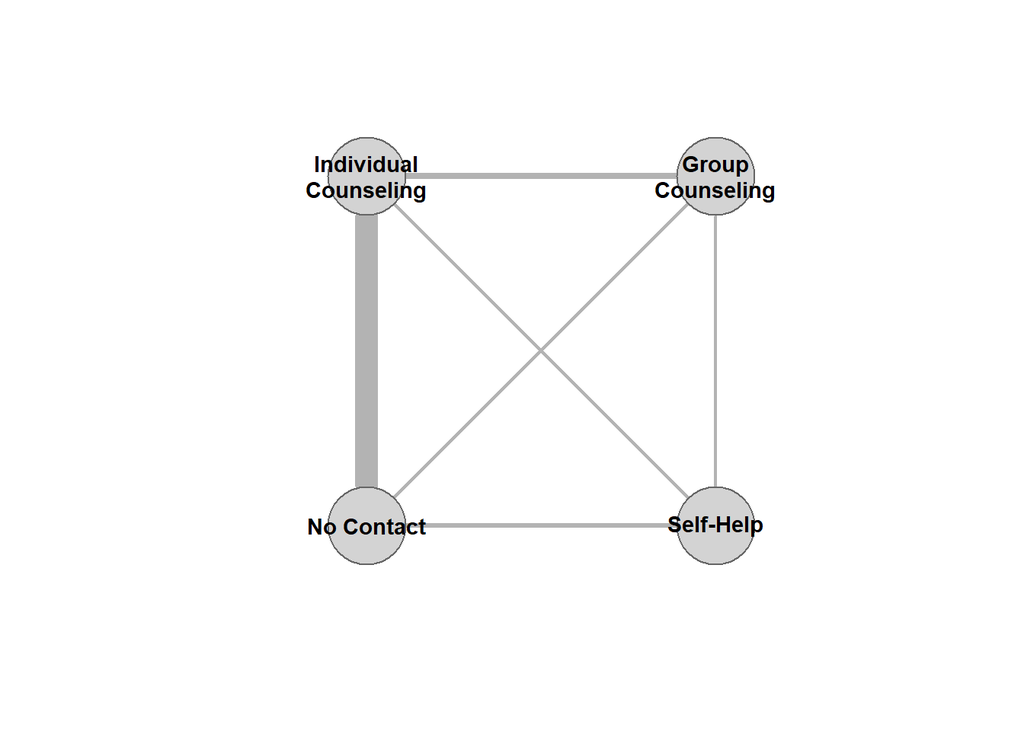

```r
# loaded here (rather than in the top-level library block) since igraph
# masks several dplyr/purrr functions used elsewhere in this document
library(igraph, warn.conflicts=FALSE)
pairs <- data.frame(do.call(rbind, sapply(split(dat$trt, dat$study), function(x) t(combn(x,2)))),
                    stringsAsFactors=FALSE)
lvls <- c("no_contact", "self_help", "ind_counseling", "grp_counseling")
pairs$X1 <- factor(pairs$X1, levels=lvls)
pairs$X2 <- factor(pairs$X2, levels=lvls)

tab <- table(pairs[,1], pairs[,2])
g <- graph_from_adjacency_matrix(tab, mode = "plus", weighted=TRUE, diag=FALSE)
vertex_attr(g, "name") <- c("No Contact",
                            "Self-Help",
                            "Individual\nCounseling",
                            "Group\nCounseling")

plot(g,
     edge.curved        = FALSE,
     edge.width         = E(g)$weight,
     edge.color         = "gray70",
     layout             = layout_on_grid,
     vertex.size        = 45,
     vertex.color       = "lightgray",
     vertex.frame.color = "gray40",
     vertex.label.color = "black",
     vertex.label.font  = 2,
     vertex.label.family = "sans",
     vertex.label.cex   = 0.9)
```

We then format the treatment variable and use no contact as the reference condition.

```r
# formatting for output
dat$trt <- factor(dat$trt, levels=c("no_contact", "self_help", "ind_counseling", "grp_counseling"))
levels(dat$trt) <- paste0(" ", levels(dat$trt))
```

We fit a one-stage arm-based network meta-analysis using a binomial GLMM with a logit link. The model uses the numbers of abstinent (`xi`) and non-abstinent individuals (`ni - xi`) in each study arm. The treatment effects compare each counselling condition with no contact, while the study-level random effects account for variation between studies.

This is an arm-based (AB) likelihood: the raw arm-level counts are modelled directly via an exact binomial distribution, rather than first reducing each study to estimated log-odds ratios pooled under a normal approximation as in the traditional contrast-based (CB) likelihood (Salanti 2012; I. R. White et al. 2019).

**Model 1: independent arm-level random effects**

The first model uses treatment-specific between-study variances with no correlation between arms of the same study (using the `diag` covariance structure).

```r
nma_fit <- glmmTMB(cbind(xi, ni-xi) ~ trt + diag(0 + trt | study),
                   family = binomial(link = "logit"),
                   data=dat)


# > summary(nma_fit)
#
#
#  Family: binomial  ( logit )
# Formula:          cbind(xi, ni - xi) ~ trt + diag(0 + trt | study)
# Data: dat
#
#       AIC       BIC    logLik -2*log(L)  df.resid
#     402.6     417.9    -193.3     386.6        42
#
# Random effects:
#
# Conditional model:
#  Groups Name               Variance Std.Dev.
#  study  trt no_contact     0.2161   0.4648
#         trt self_help      0.6245   0.7902
#         trt ind_counseling 0.5108   0.7147
#         trt grp_counseling 0.3930   0.6269
# Number of obs: 50, groups:  study, 24
#
# Conditional model:
#                    Estimate Std. Error z value Pr(>|z|)
# (Intercept)         -2.5651     0.1363 -18.813  < 2e-16 ***
# trt self_help        0.6118     0.3683   1.661 0.096652 .
# trt ind_counseling   0.8857     0.2203   4.020 5.82e-05 ***
# trt grp_counseling   1.1390     0.3211   3.548 0.000389 ***
# ---
# Signif. codes:  0 ‘***’ 0.001 ‘**’ 0.01 ‘*’ 0.05 ‘.’ 0.1 ‘ ’ 1
```

**Model 2: compound-symmetry random effects**

The second model adds a single common correlation $\rho$ between arms of the same study (using the `cs` compound-symmetry covariance structure), capturing the shared study baseline.

```r
nma_cs_fit <- glmmTMB(cbind(xi, ni-xi) ~ trt + cs(0 + trt | study),
                   family = binomial(link = "logit"),
                   data=dat)

# > summary(nma_cs_fit)
#
#
#  Family: binomial  ( logit )
# Formula:          cbind(xi, ni - xi) ~ trt + cs(0 + trt | study)
# Data: dat
#
#       AIC       BIC    logLik -2*log(L)  df.resid
#     401.3     418.5    -191.7     383.3        41
#
# Random effects:
#
# Conditional model:
#  Groups Name               Variance Std.Dev. Corr
#  study  trt no_contact     0.1858   0.4311   0.49 (cs)
#         trt self_help      0.4847   0.6962
#         trt ind_counseling 0.5443   0.7377
#         trt grp_counseling 0.5051   0.7107
# Number of obs: 50, groups:  study, 24
#
# Conditional model:
#                    Estimate Std. Error z value Pr(>|z|)
# (Intercept)         -2.4902     0.1273 -19.567  < 2e-16 ***
# trt self_help        0.5268     0.2912   1.809 0.070452 .
# trt ind_counseling   0.7796     0.1855   4.204 2.63e-05 ***
# trt grp_counseling   1.0707     0.3163   3.385 0.000711 ***
# ---
# Signif. codes:  0 ‘***’ 0.001 ‘**’ 0.01 ‘*’ 0.05 ‘.’ 0.1 ‘ ’ 1
```

```r
anova(nma_fit, nma_cs_fit)
```

|  | Df | AIC | BIC | logLik | deviance | Chisq | Chi Df | Pr(>Chisq) |
| --- | --- | --- | --- | --- | --- | --- | --- | --- |
| nma_fit | 8 | 402.5668 | 417.8629 | -193.2834 | 386.5668 | NA | NA | NA |
| nma_cs_fit | 9 | 401.3110 | 418.5193 | -191.6555 | 383.3110 | 3.255704 | 1 | 0.0711754 |

The likelihood ratio test weakly favours the compound-symmetry model (χ²₁ = 3.26, p = 0.071; ΔAIC = 1.3), and we retain it as the primary analysis since arms within a study plausibly share a common baseline. Note that the slightly larger estimates under the diagonal model reflect within-study correlation being misattributed to treatment contrasts when ignored.

```r
est <- exp(coef(summary(nma_cs_fit))$cond[,1])
ci_prof <- exp(confint(nma_cs_fit, parm="beta_", method = "profile"))

results_nma <- data.frame(
  Estimate = est,
  Lower_CI = ci_prof[, 1],
  Upper_CI = ci_prof[, 2]
)

results_nma
```

|  | Estimate | Lower_CI | Upper_CI |
| --- | --- | --- | --- |
| (Intercept) | 0.082893 | 0.0619236 | 0.1055801 |
| trt self_help | 1.693519 | 0.8972999 | 3.3346474 |
| trt ind_counseling | 2.180618 | 1.5205723 | 3.2687439 |
| trt grp_counseling | 2.917375 | 1.4199303 | 6.1399210 |

The above `confint()` call computes profile likelihood confidence intervals, which are based on the shape of the likelihood rather than the Wald (normal) approximation and are more reliable in moderate samples.

Exponentiating the profile likelihood intervals gives odds ratios versus no contact of 1.69 (95% CI 0.90–3.33) for self-help, 2.18 (1.52–3.27) for individual counselling, and 2.92 (1.42–6.14) for group counselling. Both counselling formats show evidence of benefit, while the interval for self-help includes 1, so its evidence is inconclusive.

## 2.3 Phylogenetic meta-analysis

In meta-analysis of ecological and evolutionary studies, effect sizes are often drawn from multiple species. Because species share evolutionary history, these effect size estimates are not independent. To account for this phylogenetic relatedness, we can include a species-level random effect structured by a phylogenetic correlation (which is derived from a phylogenetic tree and assumed model of evolution). We can fit such a random effect in `glmmTMB` with the `propto` covariance structure.

We will use a published meta-analysis dataset of plant diversity effects on leaf traits (Felix, Stevenson, and Koricheva 2023) to showcase how to use `glmmTMB` to fit a phylogenetic meta-analysis.

```r
library(readr)
# Source file is Latin-1 (ISO-8859-1) encoded, not UTF-8; reading it as
# UTF-8 would leave invalid bytes in character columns (e.g. `experiment`),
# which would later break base::trimws()/sub() inside orchaRd::mod_results().
ef <- read_csv("felix_data/effect_sizes.csv", locale = locale(encoding = "ISO-8859-1"))
options(na.action = "na.pass")
```

Data set-up:

```r
# loaded here (rather than in the top-level library block) to avoid
# namespace clashes between rotl/ape/dplyr and packages loaded earlier
suppressPackageStartupMessages({
  library(rotl)
  library(ape)
  library(dplyr)
})

# remove rows with missing Nfixing
ef <- ef[!is.na(ef$Nfixing), ]

# construct phylogentic tree matrix for use as random factor
species <- unique(ef$species) # list of unique species in meta-analysis
species <- as.character(species) # change to character object
taxa <- tnrs_match_names(species)
tree <- rotl::tol_induced_subtree(taxa$ott_id)
tree$tip.label <- strip_ott_ids(tree$tip.label, remove_underscores = TRUE) # change ids to the names from dataset

# calculate correlations between all species = cor
tree2 <- compute.brlen(tree)
phylo.cor <- vcv(tree2, cor = T)

# add phylo random factor
ef$phylo <- factor(ef$species, levels = rownames(phylo.cor))

# set up phylo.cor row and column names
phylo.cor <- phylo.cor[rownames(phylo.cor) %in% levels(ef$phylo),
                       colnames(phylo.cor) %in% levels(ef$phylo)]

phylo.cor <- phylo.cor[levels(ef$phylo), levels(ef$phylo)]
dimnames(phylo.cor) <- list(levels(ef$phylo), levels(ef$phylo))

# add g variable
ef$g <- 1

# derive effect size level variable => make sure it is a factor
ef$id <- as.factor(1:nrow(ef))

# set up sampling errors variance-covariance matrix
# assuming within-study a constant correlation of 0.5
V <- metafor::vcalc(vi, cluster=ACC, obs=id, data=ef, rho=0.5)
rownames(V) <- colnames(V) <- levels(ef$id)
```

**Important**

Both `phylo.cor` (used with `propto()`) and `V` (used with `equalto()`) must have row and column names matching the levels of their corresponding random effect variables (`phylo` and `id`), in the same order.

```r
phylo.cor[1:5,1:5]
```

```
                         Rhus chinensis Anacardium excelsum
Rhus chinensis                 1.000000            0.990099
Anacardium excelsum            0.990099            1.000000
Choerospondias axillaris       0.980198            0.980198
Cedrela odorata                0.960396            0.960396
Swietenia macrophylla          0.960396            0.960396
                         Choerospondias axillaris Cedrela odorata
Rhus chinensis                           0.980198        0.960396
Anacardium excelsum                      0.980198        0.960396
Choerospondias axillaris                 1.000000        0.960396
Cedrela odorata                          0.960396        1.000000
Swietenia macrophylla                    0.960396        0.990099
                         Swietenia macrophylla
Rhus chinensis                        0.960396
Anacardium excelsum                   0.960396
Choerospondias axillaris              0.960396
Cedrela odorata                       0.990099
Swietenia macrophylla                 1.000000
```

```r
V[1:5,1:5]
```

```
       1      2      3      4      5
1 0.1363 0.0678 0.0684 0.0677 0.0687
2 0.0678 0.1348 0.0680 0.0673 0.0683
3 0.0684 0.0680 0.1371 0.0679 0.0689
4 0.0677 0.0673 0.0679 0.1343 0.0682
5 0.0687 0.0683 0.0689 0.0682 0.1385
```

We fit a multilevel model in which experimental site (`experiment`), study ID (`ACC`), individual effect ID (`id`), and plant species (`species`) are included as random factors to account for non-independence among effect sizes.

This multilevel phylogenetic meta-analysis uses two covariance structures in `glmmTMB`:

- `propto`: to model shared evolutionary history across species assuming a proportional phylogenetic correlation matrix
- `equalto`: to incorporate known sampling-errors variance-covariance

```r
fit_phylo <- glmmTMB(yi ~ Nfixing-1 +
                       (1 | experiment) + (1 | ACC) +
                       (1 | species) + propto(0 + phylo|g, phylo.cor) +
                       equalto(0 + id|g, V),
                     data = ef,
                     REML=TRUE)

# Family: gaussian  ( identity )
# Formula:  yi ~ Nfixing - 1 + (1 | experiment) + (1 | ACC) + (1 | species) +
#                propto(0 + phylo | g, phylo.cor) + equalto(0 + id | g, V)
# Data: ef
#
#       AIC       BIC    logLik -2*log(L)  df.resid
#    2856.4    2890.5   -1421.2    2842.4       948
#
# Random effects:
#
# Conditional model:
#  Groups     Name                          Variance  Std.Dev.  Corr
#  experiment (Intercept)                   2.044e-01 0.4521456
#  ACC        (Intercept)                   6.535e-08 0.0002556
#  species    (Intercept)                   1.063e-01 0.3260582
#  g          phyloRhus chinensis           2.958e-01 0.5438523
#             phyloAnacardium excelsum      2.958e-01 0.5438523 0.99
#             phyloChoerospondias axillaris 2.958e-01 0.5438523 0.98 0.98
#             phyloCedrela odorata          2.958e-01 0.5438523 0.96 0.96 0.96
#             phyloSwietenia macrophylla    2.958e-01 0.5438523 0.96 0.96 0.96 0.99
#             phyloSapindus mukorossi       2.958e-01 0.5438523 0.89 0.89 0.89 0.89 0.89
#             phyloKoelreuteria bipinnata   2.958e-01 0.5438523 0.89 0.89 0.89 0.89 0.89 0.99
#             phyloAcer saccharum           2.958e-01 0.5438523 0.89 0.89 0.89 0.89 0.89 0.94 0.94
#             phyloAcer pseudoplatanus      2.958e-01 0.5438523 0.89 0.89 0.89 0.89 0.89 0.94 0.94 0.99
#             phyloAcer rubrum              2.958e-01 0.5438523 0.89 0.89 0.89 0.89 0.89 0.94 0.94 0.98 0.98
#             ...                           ...       ...       ...  ...  ...  ...  ...  ...  ...  ...  ...  ...
#  g.1        id1                           1.363e-01 0.3692337
#             id2                           1.348e-01 0.3671031 0.50
#             id3                           1.371e-01 0.3703363 0.50 0.50
#             id4                           1.343e-01 0.3664739 0.50 0.50 0.50
#             id5                           1.385e-01 0.3721760 0.50 0.50 0.50 0.50
#             id6                           1.526e-01 0.3905846 0.50 0.50 0.50 0.50 0.50
#             id7                           5.509e-01 0.7422410 0.00 0.00 0.00 0.00 0.00 0.00
#             id8                           9.201e-01 0.9591954 0.00 0.00 0.00 0.00 0.00 0.00 0.50
#             id9                           1.176e+00 1.0846430 0.00 0.00 0.00 0.00 0.00 0.00 0.50 0.50
#             id10                          1.908e+00 1.3812190 0.00 0.00 0.00 0.00 0.00 0.00 0.50 0.50 0.50
#             ...                           ...       ...       ...  ...  ...  ...  ...  ...  ...  ...  ...  ...
#  Residual                                 4.256e-01 0.6523670
# Number of obs: 955, groups:  experiment, 39; ACC, 39; species, 102; g, 1
#
# Dispersion estimate for gaussian family (sigma^2): 0.426
#
# Conditional model:
#                               Estimate Std. Error z value Pr(>|z|)
# NfixingN-fixing neighbours     0.10552    0.32404   0.326    0.745
# NfixingNo N-fixing neighbours  0.08583    0.31441   0.273    0.785
```

We can extract and view the fixed effect estimates, showing the two groups for `Nfixing` (whether neighboring plants have nitrogen fixing or not):

```r
summary(fit_phylo)$coefficients$cond
```

```
                                Estimate Std. Error   z value  Pr(>|z|)
NfixingN-fixing neighbours    0.10552475  0.3240432 0.3256502 0.7446890
NfixingNo N-fixing neighbours 0.08583235  0.3144103 0.2729948 0.7848572
attr(,"ddf")
[1] "asymptotic"
```

The variance component estimates can be obtained:

```r
# get random-effects varcor parameters
re_est <- as.data.frame(confint(fit_phylo, parm="theta_"))

# summarise random-effects variance estimates
data.frame(sigma2.experiment = round(re_est$Estimate[1]^2,4),
           sigma2.ACC = round(re_est$Estimate[2]^2,4),
           sigma2.species = round(re_est$Estimate[3]^2,4),
           sigma2.phylo = round(re_est$Estimate[4]^2,4),
           sigma2.id=round(sigma(fit_phylo)^2,4))
```

| sigma2.experiment | sigma2.ACC | sigma2.species | sigma2.phylo | sigma2.id |
| --- | --- | --- | --- | --- |
| 0.2044 | 0 | 0.1063 | 0.2958 | 0.4256 |

```r
fit_phylo_rma <- rma.mv(yi, vi,
                        mods = ~ Nfixing-1,
                        random = list( ~ 1 | experiment, ~ 1 | ACC,
                                       ~1 | species, ~1 | phylo,
                                       ~1 | id),
                        R = list(phylo = phylo.cor),
                        data = ef,
                        method="REML") #default is REML

summary(fit_phylo_rma)
```

```
Multivariate Meta-Analysis Model (k = 955; method: REML)

    logLik    Deviance         AIC         BIC        AICc
-1368.8279   2737.6557   2751.6557   2785.6731   2751.7743

Variance Components:

            estim    sqrt  nlvls  fixed      factor    R
sigma^2.1  0.0615  0.2479     39     no  experiment   no
sigma^2.2  0.0000  0.0001     39     no         ACC   no
sigma^2.3  0.2125  0.4610    102     no     species   no
sigma^2.4  0.1784  0.4224    102     no       phylo  yes
sigma^2.5  0.0266  0.1631    955     no          id   no

Test for Residual Heterogeneity:
QE(df = 953) = 1433.1312, p-val < .0001

Test of Moderators (coefficients 1:2):
QM(df = 2) = 0.8209, p-val = 0.6633

Model Results:

                               estimate      se    zval    pval    ci.lb
NfixingN-fixing neighbours       0.1759  0.2459  0.7154  0.4744  -0.3060
NfixingNo N-fixing neighbours    0.2091  0.2361  0.8856  0.3758  -0.2536
                                ci.ub
NfixingN-fixing neighbours     0.6579
NfixingNo N-fixing neighbours  0.6718

---
Signif. codes:  0 '***' 0.001 '**' 0.01 '*' 0.05 '.' 0.1 ' ' 1
```

We can store time and compare with the model fitted with `metafor`:

```r
## Fit glmmTMB model and store runtime
time_glmmTMB <- system.time(
  fit_phylo <- glmmTMB(
    yi ~ Nfixing - 1 +
      (1 | experiment) + (1 | ACC) +
      (1 | species) +
      propto(0 + phylo | g, phylo.cor) +
      equalto(0 + id | g, V),
    data = ef,
    REML = TRUE
  )
)[["elapsed"]]

## Fit rma.mv model and store runtime
time_rma <- system.time(
  fit_phylo_rma <- rma.mv(
    yi, vi,
    mods   = ~ Nfixing - 1,
    random = list(
      ~ 1 | experiment,
      ~ 1 | ACC,
      ~ 1 | species,
      ~ 1 | phylo,
      ~ 1 | id
    ),
    R      = list(phylo = phylo.cor),
    data   = ef,
    method = "REML"
  )
)[["elapsed"]]

## Put runtimes into a tidy object
runtime_df <- data.frame(
  model       = c("glmmTMB_phylo", "rma.mv_phylo"),
  runtime_sec = c(time_glmmTMB, time_rma)
)

runtime_df
```

| model | runtime_sec |
| --- | --- |
| glmmTMB_phylo | 22.00 |
| rma.mv_phylo | 281.89 |

Some notes about speeding up model fitting with `metafor`: https://www.metafor-project.org/doku.php/tips:speeding_up_model_fitting

## 2.4 Location-scale meta-analysis

In a standard random-effects meta-analysis, the between-study variance $\tau^2$ is assumed constant across studies. This is often unrealistic. **Location–scale models** relax this assumption by modelling both the *location* (the mean effect) and the *scale* (the amount of heterogeneity) as functions of study-level moderators. In practice, you can include different predictors in the mean and variance parts to test whether heterogeneity varies with study features (e.g., outcome type, design) or differs across subgroups. This yields a more flexible meta-analytic model that can explain, not just accommodate, between-study variability.

We will use a social-science meta-analysis of 48 studies on school-based writing-to-learn interventions (Bangert-Drowns, Hurley, and Wilkinson 2004). Each study contrasts an intervention group (greater emphasis on writing tasks) with a control group. The effect size measures used in this dataset is the *standardised mean differences*, where positive values indicate better academic performance under the intervention.

```r
dat <- dat.bangertdrowns2004
dat$id <- as.factor(dat$id)
dat$g <- rep(1, nrow(dat))
```

```r
V <- diag(dat$vi)
row.names(V) <- colnames(V) <- levels(dat$id)
```

**Important**

Row and column names of `V` must match the levels of the `id` random effect variable, and be in the same order.

We fit a simple location-scale meta-analysis (Viechtbauer and López-López 2022) modelling the study sample size variable (`ni`) in the location and scale parts. We use `dispformula` in `glmmTMB` to specify the scale part of the model.

```r
fit_ls <- glmmTMB(yi ~ ni + equalto(0 + id|g, V),
                  dispformula = ~ ni,
                  data = dat,
                  REML = TRUE)

# > summary(fit_ls)
#  Family: gaussian  ( identity )
# Formula:          yi ~ ni + equalto(0 + id | g, V)
# Dispersion:          ~ni
# Data: dat
#
#       AIC       BIC    logLik -2*log(L)  df.resid
#      54.6      62.0     -23.3      46.6        44
#
# Random effects:
#
# Conditional model:
#  Groups   Name Variance Std.Dev. Corr
#  g        id1  0.070    0.26458
#           id2  0.126    0.35496  0.00
#           id3  0.042    0.20494  0.00 0.00
#           id4  0.019    0.13784  0.00 0.00 0.00
#           id5  0.022    0.14832  0.00 0.00 0.00 0.00
#           id6  0.009    0.09487  0.00 0.00 0.00 0.00 0.00
#           id7  0.106    0.32558  0.00 0.00 0.00 0.00 0.00 0.00
#           id8  0.007    0.08367  0.00 0.00 0.00 0.00 0.00 0.00 0.00
#           id9  0.040    0.20000  0.00 0.00 0.00 0.00 0.00 0.00 0.00 0.00
#           id10 0.052    0.22804  0.00 0.00 0.00 0.00 0.00 0.00 0.00 0.00 0.00
#           ...  ...      ...      ...  ...  ...  ...  ...  ...  ...  ...  ...  ...
#  Residual         NA         NA
# Number of obs: 48, groups:  g, 1
#
# Conditional model:
#               Estimate Std. Error z value Pr(>|z|)
# (Intercept)  0.3016814  0.0667402   4.520 6.18e-06 ***
# ni          -0.0005527  0.0001987  -2.781  0.00542 **
# ---
# Signif. codes:  0 ‘***’ 0.001 ‘**’ 0.01 ‘*’ 0.05 ‘.’ 0.1 ‘ ’ 1
#
# Dispersion model:
#              Estimate Std. Error z value Pr(>|z|)
# (Intercept) -0.960439   0.331888  -2.894  0.00381 **
# ni          -0.004587   0.002540  -1.806  0.07095 .
# ---
# Signif. codes:  0 ‘***’ 0.001 ‘**’ 0.01 ‘*’ 0.05 ‘.’ 0.1 ‘ ’ 1
#
#
#
```

View the estimates of the location-part of the model:

```r
summary(fit_ls)$coefficients$cond
```

```
                 Estimate   Std. Error   z value     Pr(>|z|)
(Intercept)  0.3016813623 0.0667402453  4.520232 6.177203e-06
ni          -0.0005526633 0.0001987119 -2.781230 5.415341e-03
attr(,"ddf")
[1] "asymptotic"
```

View the estimates of the scale-part of the model:

```r
summary(fit_ls)$coefficients$disp
```

```
                Estimate  Std. Error   z value    Pr(>|z|)
(Intercept) -0.960439271 0.331888336 -2.893863 0.003805345
ni          -0.004587144 0.002540198 -1.805821 0.070946268
attr(,"ddf")
[1] "asymptotic"
```

We can fit the same model with `metafor` (Viechtbauer 2010) with the `rma` function and using the `scale` argument:

```r
fit_ls_rma <- rma(yi, vi,
                  mods = ~ ni,
                  scale = ~ ni,
                  control=list(REMLf=FALSE),
                  data = dat)
```

**Tip**

As before, `control=list(REMLf=FALSE)` makes the `metafor` log-likelihood directly comparable to `glmmTMB`’s.

# 3 Useful notes and links

## Robust variance estimation

`vcovHC()` is a function in `glmmTMB` that computes robust (sandwich) variance-covariance matrices for the fixed effects estimates. This can be particularly useful when there is concern about model misspecification or when the data exhibit heteroscedasticity or clustering that is not fully accounted for by the random effects structure.

More information is provided here: [Post-model-fitting procedures with glmmTMB](https://cran.r-project.org/web/packages/glmmTMB/vignettes/model_evaluation.pdf)

Important note: currently `glmmTMB` doesn’t support small sample adjustments (though it may be added in future developments).

## Changing optimization method

In some cases, the default optimization method may not converge or can yield warning messages. In such cases, you can try alternative optimization methods by modifying the `control = glmmTMBControl()` argument. By default, `glmmTMB` uses the `nlminb` non-linear optimizer for parameter estimation.

Further information on optimization methods and troubleshooting convergence and warning messages can be found in the `glmmTMB` documentation:

- [Troubleshooting with glmmTMB](https://cran.r-project.org/web/packages/glmmTMB/vignettes/troubleshooting.html)

## Other covariance structures

The `glmmTMB` package offers a variety of covariance structures that can be used to model different types of dependencies in the data. A list of available covariance structures and their applications can be found in the package documentation:

- [Covariance structures with glmmTMB](https://cran.r-project.org/web/packages/glmmTMB/vignettes/covstruct.html)

## Orchard plots with glmmTMB

Orchard plots are extensions of forest plots that display model estimates, confidence and prediction intervals, and the distribution of individual effect sizes (Nakagawa et al. 2023). To demonstrate how to produce orchard plots with the `orchaRd` package, we use the phylogenetic meta-analysis example and plot the estimated effects for the two plant groups: N-fixing and non-N-fixing species.

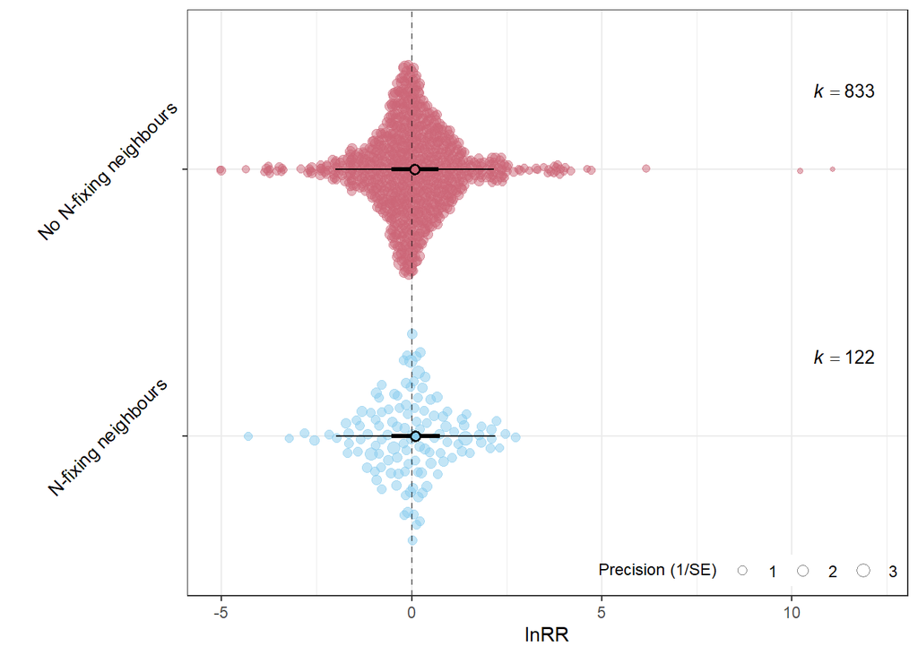

```r
## As of July 2026: you need to use the following branch
#detach("package:orchaRd", unload = TRUE)
#remove.packages("orchaRd")
#devtools::install_github("daniel1noble/orchaRd", ref = "glmmtmb-rma-adapter", force = TRUE)

library(orchaRd)
tmb.res <- glmmTMB_to_rma(fit_phylo,
               yi = "yi",
               vi = "vi",
               data = ef)


tmb.Nfixing <- orchaRd::mod_results(
  tmb.res,
  mod = "Nfixing",
  group = "experiment"
)

orchaRd::orchard_plot(
  tmb.Nfixing,
  xlab = "lnRR",
  angle = 45,
  g = FALSE
)
```

# 4 References

Bangert-Drowns, Robert L., Marlene M. Hurley, and Barbara Wilkinson. 2004. “The Effects of School-Based Writing-to-Learn Interventions on Academic Achievement: A Meta-Analysis.” *Review of Educational Research* 74 (1): 29–58. https://doi.org/10.3102/00346543074001029.

Brooks, Mollie E., Kasper Kristensen, Koen J. van Benthem, Arni Magnusson, Casper W. Berg, Anders Nielsen, Hans J. Skaug, Martin Mächler, and Benjamin M. Bolker. 2017. “glmmTMB Balances Speed and Flexibility Among Packages for Zero-Inflated Generalized Linear Mixed Modeling.” *The R Journal* 9 (2): 378–400. https://doi.org/10.32614/RJ-2017-066.

Colditz, Graham A., Timothy F. Brewer, Catherine S. Berkey, Mary E. Wilson, Elizabeth Burdick, Harvey V. Fineberg, and Frederick Mosteller. 1994. “Efficacy of BCG Vaccine in the Prevention of Tuberculosis: Meta-Analysis of the Published Literature.” *Journal of the American Medical Association* 271 (9): 698–702. https://doi.org/10.1001/jama.1994.03510330076038.

Felix, Jean-Ann, Philip C. Stevenson, and Julia Koricheva. 2023. “Plant Neighbourhood Diversity Effects on Leaf Traits: A Meta-Analysis.” *Functional Ecology* 37 (12): 3150–63. https://doi.org/10.1111/1365-2435.14441.

Hasselblad, Vic. 1998. “Meta-Analysis of Multitreatment Studies.” *Medical Decision Making* 18 (1): 37–43. https://doi.org/10.1177/0272989X9801800110.

Nakagawa, Shinichi, Malgorzata Lagisz, Rose E. O’Dea, Patrice Pottier, Joanna Rutkowska, Alistair M. Senior, Yefeng Yang, and Daniel W. A. Noble. 2023. “orchaRd 2.0: An R Package for Visualising Meta-Analyses with Orchard Plots.” *Methods in Ecology and Evolution* 14 (8). https://doi.org/10.1111/2041-210X.14152.

Salanti, Georgia. 2012. “Indirect and Mixed-Treatment Comparison, Network, or Multiple-Treatments Meta-Analysis: Many Names, Many Benefits, Many Concerns for the Next Generation Evidence Synthesis Tool.” *Research Synthesis Methods* 3 (2): 80–97. https://doi.org/10.1002/jrsm.1037.

Viechtbauer, Wolfgang. 2010. “Conducting Meta-Analyses in R with the metafor Package.” *Journal of Statistical Software* 36 (3): 1–48. https://doi.org/10.18637/jss.v036.i03.

Viechtbauer, Wolfgang, and José Antonio López-López. 2022. “Location-Scale Models for Meta-Analysis.” *Research Synthesis Methods* 13 (6): 697–715. https://doi.org/10.1002/jrsm.1562.

White, Ian R., Rebecca M. Turner, Amalia Karahalios, and Georgia Salanti. 2019. “A Comparison of Arm-Based and Contrast-Based Models for Network Meta-Analysis.” *Statistics in Medicine* 38 (27): 5197–5213. https://doi.org/10.1002/sim.8360.

White, Thomas, Daniel Noble, Alistair Senior, William Hamilton, and Wolfgang Viechtbauer. 2022. *Metadat: Meta-Analysis Datasets*. https://CRAN.R-project.org/package=metadat.

# 5 Session info

```r
library(sessioninfo)
library(details)


suppressWarnings(
  details::details(session_info(), summary = 'Current session info', open = FALSE)
)
```

**Current session info**

```r
─ Session info ───────────────────────────────────────────────────────────────
 setting  value
 version  R version 4.6.1 (2026-06-24 ucrt)
 os       Windows 11 x64 (build 26200)
 system   x86_64, mingw32
 ui       RTerm
 language (EN)
 collate  English_Australia.utf8
 ctype    English_Australia.utf8
 tz       Australia/Sydney
 date     2026-09-26
 pandoc   3.10 @ c:\\Program Files\\Positron\\resources\\app\\quarto\\bin\\tools/ (via rmarkdown)
 quarto   1.5.57 @ C:\\Users\\z5394590\\AppData\\Local\\Programs\\Quarto\\bin\\quarto.exe

─ Packages ───────────────────────────────────────────────────────────────────
 ! package      * version    date (UTC) lib source
   ape          * 5.8-1      2024-12-16 [1] CRAN (R 4.6.1)
   beeswarm       0.4.0      2021-06-01 [1] CRAN (R 4.6.0)
   bit            4.6.0      2025-03-06 [1] CRAN (R 4.6.1)
   bit64          4.8.2      2026-05-19 [1] CRAN (R 4.6.1)
   boot           1.3-32     2025-08-29 [2] CRAN (R 4.6.1)
   cli            3.6.6      2026-04-09 [1] CRAN (R 4.6.1)
   clipr          0.8.1      2026-05-25 [1] CRAN (R 4.6.1)
   coda           0.19-4.1   2024-01-31 [1] CRAN (R 4.6.1)
   codetools      0.2-20     2024-03-31 [2] CRAN (R 4.6.1)
   crayon         1.5.3      2024-06-20 [1] CRAN (R 4.6.1)
   curl           7.1.0      2026-04-22 [1] CRAN (R 4.6.1)
   desc           1.4.3      2023-12-10 [1] CRAN (R 4.6.1)
   details      * 0.4.0      2025-02-09 [1] CRAN (R 4.6.1)
   digest         0.6.39     2025-11-19 [1] CRAN (R 4.6.1)
   dplyr        * 1.2.1      2026-04-03 [1] CRAN (R 4.6.1)
   emmeans        2.0.4      2026-07-15 [1] CRAN (R 4.6.1)
   estimability   2.0.0      2026-06-26 [1] CRAN (R 4.6.1)
   evaluate       1.0.5      2025-08-27 [1] CRAN (R 4.6.1)
   farver         2.1.2      2024-05-13 [1] CRAN (R 4.6.1)
   fastmap        1.2.0      2024-05-15 [1] CRAN (R 4.6.1)
   forcats      * 1.0.1      2025-09-25 [1] CRAN (R 4.6.1)
   generics       0.1.4      2025-05-09 [1] CRAN (R 4.6.1)
   ggbeeswarm     0.7.3      2025-11-29 [1] CRAN (R 4.6.1)
   ggplot2      * 4.0.3      2026-04-22 [1] CRAN (R 4.6.1)
   glmmTMB      * 1.1.14     2026-01-15 [1] CRAN (R 4.6.1)
   glue           1.8.1      2026-04-17 [1] CRAN (R 4.6.1)
   gtable         0.3.6      2024-10-25 [1] CRAN (R 4.6.1)
   hms            1.1.4      2025-10-17 [1] CRAN (R 4.6.1)
   htmltools      0.5.9      2025-12-04 [1] CRAN (R 4.6.1)
   htmlwidgets    1.6.4      2023-12-06 [1] CRAN (R 4.6.1)
   httr           1.4.8      2026-02-13 [1] CRAN (R 4.6.1)
   igraph       * 2.3.3      2026-06-26 [1] CRAN (R 4.6.1)
   jsonlite       2.0.0      2025-03-27 [1] CRAN (R 4.6.1)
   kableExtra   * 1.4.1      2026-07-08 [1] CRAN (R 4.6.1)
   knitr          1.52       2026-09-06 [1] CRAN (R 4.6.1)
   labeling       0.4.3      2023-08-29 [1] CRAN (R 4.6.0)
   latex2exp      0.9.8      2026-01-09 [1] CRAN (R 4.6.1)
   lattice        0.22-9     2026-02-09 [2] CRAN (R 4.6.1)
   lifecycle      1.0.5      2026-01-08 [1] CRAN (R 4.6.1)
   lme4           2.0-6      2026-07-16 [1] CRAN (R 4.6.1)
   lubridate    * 1.9.5      2026-02-04 [1] CRAN (R 4.6.1)
   magrittr       2.0.5      2026-04-04 [1] CRAN (R 4.6.1)
   MASS         * 7.3-65     2025-02-28 [2] CRAN (R 4.6.1)
   mathjaxr       2.0-0      2025-12-01 [1] CRAN (R 4.6.0)
 R Matrix       * 1.7-5      <NA>       [2] <NA>
   metadat      * 1.6-0      2026-04-29 [1] CRAN (R 4.6.1)
   metafor      * 5.0-1      2026-04-26 [1] CRAN (R 4.6.1)
   mgcv           1.9-4      2025-11-07 [2] CRAN (R 4.6.1)
   minqa          1.2.8      2024-08-17 [1] CRAN (R 4.6.1)
   multcomp       1.4-32     2026-08-21 [1] CRAN (R 4.6.1)
   mvtnorm        1.4-2      2026-07-12 [1] CRAN (R 4.6.1)
   nlme           3.1-169    2026-03-27 [2] CRAN (R 4.6.1)
   nloptr         2.2.1      2025-03-17 [1] CRAN (R 4.6.1)
   numDeriv     * 2016.8-1.1 2019-06-06 [1] CRAN (R 4.6.0)
   orchaRd      * 2.2.1      2026-07-23 [1] CRAN (R 4.6.1)
   otel           0.2.0      2025-08-29 [1] CRAN (R 4.6.1)
   pillar         1.11.1     2025-09-17 [1] CRAN (R 4.6.1)
   pkgconfig      2.0.3      2019-09-22 [1] CRAN (R 4.6.1)
   png            0.1-9      2026-03-15 [1] CRAN (R 4.6.0)
   prettyunits    1.2.0      2023-09-24 [1] CRAN (R 4.6.1)
   progress       1.2.3      2023-12-06 [1] CRAN (R 4.6.1)
   purrr        * 1.2.2      2026-04-10 [1] CRAN (R 4.6.1)
   R6             2.6.1      2025-02-15 [1] CRAN (R 4.6.1)
   rbibutils      2.4.1      2026-01-21 [1] CRAN (R 4.6.1)
   RColorBrewer   1.1-3      2022-04-03 [1] CRAN (R 4.6.0)
   Rcpp           1.1.2      2026-07-05 [1] CRAN (R 4.6.1)
   Rdpack         2.6.6      2026-02-08 [1] CRAN (R 4.6.1)
   readr        * 2.2.0      2026-02-19 [1] CRAN (R 4.6.1)
   reformulas     0.4.4      2026-02-02 [1] CRAN (R 4.6.1)
   rentrez        1.2.4      2025-06-11 [1] CRAN (R 4.6.1)
   rlang          1.3.0      2026-07-05 [1] CRAN (R 4.6.1)
   rmarkdown      2.31       2026-03-26 [1] CRAN (R 4.6.1)
   rncl           0.8.9      2026-01-21 [1] CRAN (R 4.6.1)
   rotl         * 3.1.1      2026-01-15 [1] CRAN (R 4.6.1)
   rstudioapi     0.19.0     2026-06-11 [1] CRAN (R 4.6.1)
   S7             0.2.2      2026-04-22 [1] CRAN (R 4.6.1)
   sandwich       3.1-2      2026-07-12 [1] CRAN (R 4.6.1)
   scales         1.4.0      2025-04-24 [1] CRAN (R 4.6.1)
   sessioninfo  * 1.2.4      2026-06-04 [1] CRAN (R 4.6.1)
   stringi        1.8.7      2025-03-27 [1] CRAN (R 4.6.0)
   stringr      * 1.6.0      2025-11-04 [1] CRAN (R 4.6.1)
   survival       3.8-6      2026-01-16 [2] CRAN (R 4.6.1)
   svglite        2.2.2      2025-10-21 [1] CRAN (R 4.6.1)
   systemfonts    1.3.2      2026-03-05 [1] CRAN (R 4.6.1)
   textshaping    1.0.5      2026-03-06 [1] CRAN (R 4.6.1)
   TH.data        1.1-5      2025-11-17 [1] CRAN (R 4.6.1)
   tibble       * 3.3.1      2026-01-11 [1] CRAN (R 4.6.1)
   tidyr        * 1.3.2      2025-12-19 [1] CRAN (R 4.6.1)
   tidyselect     1.2.1      2024-03-11 [1] CRAN (R 4.6.1)
   tidyverse    * 2.0.0      2023-02-22 [1] CRAN (R 4.6.1)
   timechange     0.4.0      2026-01-29 [1] CRAN (R 4.6.1)
   TMB            1.9.21     2026-03-23 [1] CRAN (R 4.6.1)
   tzdb           0.5.0      2025-03-15 [1] CRAN (R 4.6.1)
   vctrs          0.7.3      2026-04-11 [1] CRAN (R 4.6.1)
   vipor          0.4.7      2023-12-18 [1] CRAN (R 4.6.1)
   viridisLite    0.4.3      2026-02-04 [1] CRAN (R 4.6.1)
   vroom          1.7.1      2026-03-31 [1] CRAN (R 4.6.1)
   withr          3.0.3      2026-06-19 [1] CRAN (R 4.6.1)
   xfun           0.60       2026-07-09 [1] CRAN (R 4.6.1)
   XML            3.99-0.23  2026-03-20 [1] CRAN (R 4.6.0)
   xml2           1.6.0      2026-06-22 [1] CRAN (R 4.6.1)
   xtable         1.8-8      2026-02-22 [1] CRAN (R 4.6.1)
   yaml           2.3.12     2025-12-10 [1] CRAN (R 4.6.1)
   zoo            1.8-15     2025-12-15 [1] CRAN (R 4.6.1)

 [1] C:/Users/z5394590/AppData/Local/R/win-library/4.6
 [2] C:/Program Files/R/R-4.6.1/library

 * ── Packages attached to the search path.
 R ── Package was removed from disk.

──────────────────────────────────────────────────────────────────────────────
```